# Module format Parquet

# 4 Manipuler des fichiers parquets avec duckdb

## 4.1 Qu’est-ce que duckdb ?

DuckDB est un projet open-source qui propose un moteur SQL optimisé pour **réaliser des travaux d’analyse statistique sur des bases de données**.

Plusieurs avantages :

- Un **moteur portable** utilisable avec **plusieurs langages** (R, Python, Javascript…) et **plusieurs OS** (Windows, Linux, MacOS…)
- Une **installation** et une **utilisation** très **facile**
- Un **moteur SQL** capable d’utiliser des données au format Parquet **sans les charger complètement en mémoire**.

**Note**

Il faut bien distinguer le projet DuckDB du package R duckdb qui propose simplement une façon d’utiliser Duckdb avec R.

## 4.2 À quoi sert le package duckdb + installation ?

**Du point de vue d’un statisticien utilisant R, le package duckdb permet de faire trois choses :**

- Importer des données (exemples: fichiers CSV, fichiers Parquet)
- Manipuler des données avec la syntaxe dplyr, ou avec le langage SQL
- Écrire des données au format Parquet.

**Installation de duckdb**

Il suffit d’installer le package duckdb, qui contient à la fois DuckDB et une interface pour que R puisse s’y connecter.

Bonne nouvelle sur la version de Cerise mis à disposition en 2025, le package duckdb sera installé par défaut ! 🎉

## 4.3 Connexions avec duckdb

**Pour utiliser duckdb, il n’est pas nécessaire de connaître le langage SQL car il est possible d’utiliser duckdb avec la syntaxe dplyr.**

duckdb est une base de données distante et s’utilise comme telle : il faut ouvrir une connexion, puis “charger” les données dans la base de données pour les manipuler.

```r
con <- DBI::dbConnect(drv = duckdb::duckdb())
```

Plusieurs remarques :

- Cette commande crée une nouvelle base de données duckdb **dans la mémoire vive**.
- Cette base de données ne contient aucune donnée lorsqu’elle est créée. L’objet `con` apparaît dans l’onglet Data de l’environnement RStudio, mais la liste des tables n’y est pas directement accessible

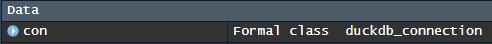

## 4.4 Déconnexion avec duckdb

À la fin du traitement ou du programme, on ferme la connexion avec le code ci-dessous. L’option `shutdown` est importante : elle permet de fermer complètement la session duckdb et de libérer la mémoire utilisée.

```r
DBI::dbDisconnect(con, shutdown = TRUE)
```

**Important**

Si on n’utilise pas cette option, il arrive souvent que des connexions à moitié ouvertes continuent à consommer des ressources !!!

## 4.5 Chargement de données issues de la session R

**La fonction `duckdb_register()` permet de charger dans duckdb des données présentes en mémoire dans la session R.**

Cette méthode a l’avantage de ne pas recopier les données: elle se contente d’établir un lien logique entre la base de données duckdb et un objet de la session R.

L’objet créé dans la base est **une vue** dans le catalogue “temp”. La durée d’existence de cette vue est le temps de la connexion.

```r
# Création de la vue "RA2020_duckdb"
con |> duckdb::duckdb_register(
  name = "RA2020_duckdb",
  df = RA2020)
```

## 4.6 Accéder à une table d’une base DuckDB

Pour vérifier que le chargement des données a bien fonctionné, **la fonction `tbl()` permet d’accéder à une table de la base de données grâce à son nom (entre double quotes).**

```r
con |> tbl("RA2020_duckdb")

# Source:   table<RA2020_duckdb> [?? x 255]
# Database: DuckDB v1.1.0 [damien.dotta@Windows 10 x64:R 4.3.0/:memory:]
   NOM_DOSSIER TYPE_QUESTIONNAIRE SEUIL_IFS CHAMP_GEO COEF_F NUMSTRATE  STRATE     SIEGENAT SIEGE_CODE_COM SIEGE_LIEUDIT
   <chr>       <chr>              <chr>     <chr>      <dbl> <chr>      <chr>      <chr>    <chr>          <chr>
 1 AAAAAAA     2                  1         1           1.22 2500000004 25000ERICA 10       14406          NA
 2 BBBBBBB     2                  1         1          10.3  2105161843 2105161843 10       51303          NA
 3 CCCCCCC     3                  1         2           1    0101030406 EXH_GEO    10       97407          CHEMIN DES ANGLAIS
```

## 4.7 Chargement de données sur le disque au format Parquet (1/2)

Pour charger des données situés sur Cerise par exemple, la fonction `tbl()` peut aussi être directement utilisée en renseignant le chemin du fichier Parquet.

```r
con %>% tbl("read_parquet('data/RA2020_exploitations.parquet')")
# Ou plus succinct (pas besoin de read_parquet() si pas besoin d'y passer des arguments)
con %>% tbl('data/RA2020_exploitations.parquet')

# Source:   SQL [?? x 255]
# Database: DuckDB v1.1.0 [damien.dotta@Windows 10 x64:R 4.3.0/:memory:]
   NOM_DOSSIER TYPE_QUESTIONNAIRE SEUIL_IFS CHAMP_GEO COEF_F NUMSTRATE  STRATE     SIEGENAT SIEGE_CODE_COM SIEGE_LIEUDIT
   <chr>       <chr>              <chr>     <chr>      <dbl> <chr>      <chr>      <chr>    <chr>          <chr>
 1 AAAAAAA     2                  1         1           1.22 2500000004 25000ERICA 10       14406          NA
 2 BBBBBBB     2                  1         1          10.3  2105161843 2105161843 10       51303          NA
 3 CCCCCCC     3                  1         2           1    0101030406 EXH_GEO    10       97407          CHEMIN DES ANGLAIS
```

## 4.8 Chargement de données sur le disque au format Parquet (2/2)

Avec des fichiers partitionnés, on peut utiliser la syntaxe suivante.  
`**/*.parquet` est un motif qui indique que vous souhaitez lire, dans tous les sous-dossiers quelque soit le niveau (`**`), l’ensemble des fichiers parquets (`*.parquet`) qui s’y trouvent.

```r
con %>% tbl('data/msa_ns/**/*.parquet')

# Source:   SQL [?? x 293]
# Database: DuckDB v1.1.0 [damien.dotta@Windows 10 x64:R 4.3.0/:memory:]
   A_IDENT         DEPT  RESID CANTON COMMUNE DOM_FISC SUP   NAF     SMI SITU_FAM NAIS_JO NAIS_MO NAIS_AN AF_MAJ AF_MIN AF_AVA
   <chr>           <chr> <chr> <chr>  <chr>      <dbl> <chr> <chr> <dbl>    <dbl> <chr>   <chr>   <chr>    <dbl>  <dbl>  <dbl>
 1 XXXXXXXXXXXXXX… 11    11    10     288            1 0     NA        0        1 25      05      1969         0      0      0
 2 YYYYYYYYYYYYYY… 11    11    01     281            1 2903  NA        0        1 30      01      2000         0      0      0
 3 ZZZZZZZZZZZZZZ… 11    11    16     269            1 368   NA        0        1 07      01      2000         0      0      0
```

## 4.9 Afficher la liste des tables d’une base Duckdb (1/2)

La fonction `dbListTables()` est utile pour afficher les noms des tables présentes dans une base de données.

Une illustration pour mieux comprendre :

```r
# On se déconnecte
DBI::dbDisconnect(con, shutdown = TRUE)

# On crée une nouvelle connexion
con <- DBI::dbConnect(drv = duckdb::duckdb())

# Affichage de la liste des tables
dbListTables(con)
# > character(0)

con |> duckdb::duckdb_register(
  name = "iris_duckdb",
  df = iris)

con %>% tbl("read_parquet('data/RA2020_exploitations.parquet')")
```

=> Question : combien de tables va maintenant renvoyer la fonction `dbListTables()` ?

## 4.10 Afficher la liste des tables d’une base Duckdb (2/2)

Réponse… UNE SEULE !

```r
# Affichage de la liste des tables
dbListTables(con)
# > "iris_duckdb"

# On se déconnecte
DBI::dbDisconnect(con, shutdown = TRUE)
```

**En effet, lorsqu’on utilise la fonction `tbl()`, celle-ci ne charge pas les données ni dans la mémoire de R ni dans celle de DuckDB.**

## 4.11 Afficher la liste des colonnes d’une table d’une base Duckdb

La fonction `dbListFields()` est utile pour afficher les noms des colonnes d’une table présente dans une base de données.

```r
# On crée une nouvelle connexion
con <- DBI::dbConnect(drv = duckdb::duckdb())

con |> duckdb::duckdb_register(
  name = "iris_duckdb",
  df = iris)

con |> DBI::dbListFields("iris_duckdb")
# > [1] "Sepal.Length" "Sepal.Width"  "Petal.Length" "Petal.Width"  "Species"

# On se déconnecte
DBI::dbDisconnect(con, shutdown = TRUE)
```

## 4.12 Accéder aux logical_types des colonnes d’un fichier parquet avec duckdb

En complément des instructions déjà vues dans la partie 2 de la formation, on peut accéder aux logical_types des colonnes d’un fichier Parquet en utilisant la requête suivante :

```r
con <- DBI::dbConnect(drv = duckdb::duckdb())
dbGetQuery(con, "DESCRIBE FROM read_parquet('data/output.parquet')")

# column_name column_type null  key default extra
# 1    colonne1      DOUBLE  YES <NA>    <NA>  <NA>
# 2    colonne2     VARCHAR  YES <NA>    <NA>  <NA>
# 3    colonne3     BOOLEAN  YES <NA>    <NA>  <NA>
# 4    colonne4        DATE  YES <NA>    <NA>  <NA>
```

Remarque : **La fonction dbGetQuery() du package DBI permet de récupérer un data.frame dont le contenu est le résultat d’une requête.**

## 4.13 Accéder aux métadonnées générales d’un fichier parquet avec duckdb

La fonction `parquet_metadata()` peut également être utilisée dans une requête écrite avec duckdb :

```r
con <- DBI::dbConnect(drv = duckdb::duckdb())
dbGetQuery(con, "SELECT * FROM parquet_metadata('data/fr_immp_transactions.parquet')")
```

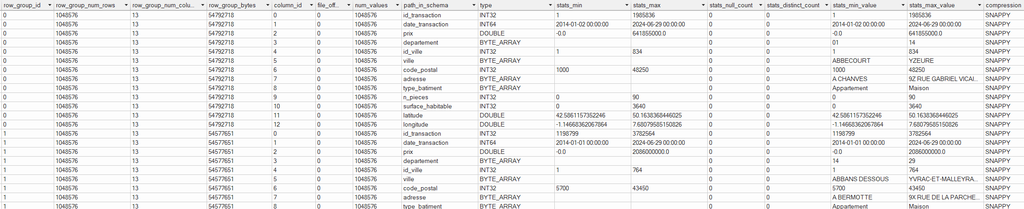

=> On retrouve des informations très intéressantes sur le mode de compression utilisé lors de l’écriture du fichier Parquet (SNAPPY), des statistiques sur les row groups (min, max), l’encodage…

## 4.14 Requêtage avec dplyr

Le package R duckdb a été écrit de façon à pouvoir manipuler les données avec la syntaxe de dplyr, c’est très pratique !

Comme avec le package {arrow} on utilise cette syntaxe avec les fonctions `collect()` ou `compute()`.

```r
# On crée une nouvelle connexion
con <- DBI::dbConnect(drv = duckdb::duckdb())

# Etablissement de la connexion au fichier Parquet
RA2020_dataset <- con %>% tbl('data/RA2020_exploitations.parquet')

# Traitement avec dplyr et un collect()
resultat <- RA2020_dataset |>
  filter(SIEGE_REG == "93") |>
  group_by(SIEGE_DEP) |>
  summarise(total_SAU = sum(SAU_TOT, na.rm = TRUE)) |>
  collect()

# On se déconnecte
DBI::dbDisconnect(con, shutdown = TRUE)
```

```r
> resultat
# A tibble: 6 × 2
  SIEGE_DEP total_SAU
  <chr>         <dbl>
1 84          112888.
2 05           91979.
3 04          158946.
4 13          145713.
5 83           77785.
6 06           41141.
```

## 4.15 Examen de la requête SQL construite par duckdb

Quand on manipule des objets avec duckdb, on construit des requêtes SQL.  
Le package duckdb se contente de traduire le code dplyr en SQL.  
La fonction `show_query()` permet de consulter la requête SQL qui a été exécutée par duckdb.

```r
# Traitement avec dplyr et un collect()
resultat <- RA2020_dataset |>
  filter(SIEGE_REG == "93") |>
  group_by(SIEGE_DEP) |>
  summarise(total_SAU = sum(SAU_TOT, na.rm = TRUE)) |>
  show_query()

# > <SQL>
SELECT SIEGE_DEP, SUM(SAU_TOT) AS total_SAU
FROM "data/RA2020_exploitations.parquet"
WHERE (SIEGE_REG = '93')
GROUP BY SIEGE_DEP
```

## 4.16 Requêtage avec SQL

Si vous avez des connaissances en SQL, il est bien sûr tout à fait possible de requêter une base DuckDB avec ce langage.  
La requête est alors passée dans la fonction `DBI::dbGetQuery()` :

```r
# On crée une nouvelle connexion
con <- DBI::dbConnect(drv = duckdb::duckdb())

chemin_donnees <- 'C:/Users/damien.dotta/DEMESIS/Formations_R/Formation_R_perfectionnement/formation-R-perf-06-parquet/data'

# Execution de la requete
resultatSQL <- DBI::dbGetQuery(
   con,
   paste0("SELECT SIEGE_DEP, SUM(SAU_TOT) AS total_SAU
    FROM '", file.path(chemin_donnees,'RA2020_exploitations.parquet'),"'
    WHERE (SIEGE_REG = '93')
    GROUP BY SIEGE_DEP"))
# resultatSQL est un data.frame directement utilisable dans R
```

## 4.17 Sauvegarder des résultats intermédiaires - dans des fichiers Parquet

**Lorsque le traitement est long, vous devez le découper et stocker quelque part vos résulats intermédiaires de manière à ne pas tout recalculer entièrement à chaque fois.**

1. Une 1ère solution consiste à écrire ces résultats intermédiaires dans des fichiers Parquet :

```r
# On crée une nouvelle connexion
con <- DBI::dbConnect(drv = duckdb::duckdb())

# Etablissement de la connexion au fichier Parquet
RA2020_dataset <- con %>% tbl('data/RA2020_exploitations.parquet')

# A la fin du traitement, on écrit un fichier parquet intermédiaire
RA2020_dataset |>
  filter(SIEGE_REG == "93") |>
  # Conversion dans un format compatible avec arrow
  arrow::to_arrow() |>
  arrow::write_parquet("data/table_intermediaire.parquet")
```

```r
# Reprise des traitements + tard avec le moteur SQL de duckdb
final <- arrow::open_dataset("data/table_intermediaire.parquet") |>
  # Conversion dans un format compatible avec duckdb
  arrow::to_duckdb(con) |>
  group_by(SIEGE_DEP) |>
  summarise(total_SAU = sum(SAU_TOT, na.rm = TRUE)) |>
  collect()

# On se déconnecte
DBI::dbDisconnect(con, shutdown = TRUE)
```

## 4.18 Sauvegarder des résultats intermédiaires - avec une BDD

2. Une 2ème solution consiste à écrire dans une BDD ces résultats intermédiaires :

```r
# On crée une nouvelle connexion
# + création d'une BDD vide avec le paramètre dbdir
con <- DBI::dbConnect(drv = duckdb::duckdb(),
                      dbdir = "data/BDD_formation.db")

# Etablissement de la connexion au fichier Parquet
RA2020_dataset <- con %>% tbl('data/RA2020_exploitations.parquet')

# Traitement avec dplyr et un compute()
RA2020_dataset |>
  filter(SIEGE_REG == "93") |>
  compute(name = "resultat_interm",
          temporary = FALSE)
```

```r
# Affichage de la liste des tables
dbListTables(con)
# [1] "resultat_interm"

# Reprise des traitements + tard avec le moteur SQL de duckdb
final2 <- con |> tbl("resultat_interm") |>
  group_by(SIEGE_DEP) |>
  summarise(total_SAU = sum(SAU_TOT, na.rm = TRUE)) |>
  collect()

# On se déconnecte
DBI::dbDisconnect(con, shutdown = TRUE)
```

## 4.19 A retenir sur les 2 méthodes de sauvegarde des résultats intermédiaires

- La première méthode avec **{arrow} et la sauvegarde dans des fichiers Parquet** est généralement **la plus rapide**.
- La seconde avec **compute() et la sauvegarde dans une BDD** est **la plus efficace en terme d’occupation mémoire**.

## 4.20 Options à utiliser

Lors d’une connexion à une base, des paramètres de `dbConnect()` peuvent être très utiles lorsqu’on travaille sur un espace comme Cerise où les ressources sont partagées.

Par exemple :

```r
con_dbnew <- dbConnect(
  drv = duckdb::duckdb(),
  dbdir=db_file,
  config=list("memory_limit"="10GB", # On définit un plafond de 10Go de RAM
              threads = "4")) # On plafonne l'utilise par duckdb de 4 coeurs (sur les 30 dispos sur Cerise)
```

## 4.21 Consulter le contenu d’une base

Reprenons la base `BDD_formation.db` créée précédemment.

```r
# On crée une nouvelle connexion
con <- DBI::dbConnect(drv = duckdb::duckdb(),
                      dbdir = "data/BDD_formation.db")

# Affichage de la liste des tables
dbListTables(con)
# > [1] "resultat_interm"
```

Ajoutons-y une vue :

```r
# Création de la vue "RA2020_duckdb"
con |> duckdb::duckdb_register(
  name = "RA2020_duckdb",
  df = RA2020)
```

```r
# Affichage de la liste des tables
dbListTables(con)
# > [1] "RA2020_duckdb"   "resultat_interm"
```

Qu’en est-il vraiment ?

```r
DBI::dbGetQuery(con,"SELECT * FROM INFORMATION_SCHEMA.TABLES")
# table_catalog table_schema      table_name table_type
1 BDD_formation         main resultat_interm BASE TABLE
2          temp         main   RA2020_duckdb       VIEW
```

=> Après déconnexion, seule la table “resultat_interm” sera conservée dans la BDD.

```r
# On se déconnecte
DBI::dbDisconnect(con, shutdown = TRUE)
```

## 4.22 Requêter des données Parquet extérieures (data.gouv) avec Cerise et duckdb (1/5)

Un exemple de code pour requêter directement la base Parquet des bureaux de vote directement depuis Cerise !!!

Configuration générale :

```r
# Installation d'une version récente de duckdb
install.packages("duckdb", repos = "https://packagemanager.posit.co/cran/__linux__/centos8/latest")

library(duckdb) ; library(glue)
cnx <- dbConnect(duckdb())

# Vérification de la version du package
dbGetQuery(cnx, "select version()")

dbExecute(cnx, "
  SET http_proxy='http://rie.proxy.national.agri:8080';
  SET http_proxy_username='${AGRICOLL_U}';
  SET http_proxy_password='${AGRICOLL_P}'")

# Installation et chargement de l'extension nécessaire httpfs
dbExecute(cnx, "INSTALL httpfs")
dbExecute(cnx, "LOAD httpfs")
```

## 4.23 Requêter des données Parquet extérieures (data.gouv) avec Cerise et duckdb (2/5)

Requête :

```r
dataset <- "https://static.data.gouv.fr/resources/bureaux-de-vote-et-adresses-de-leurs-electeurs/20230626-135723/table-adresses-reu.parquet"

dbGetQuery(cnx, glue("DESCRIBE FROM '{dataset}'"))

dbDisconnect(cnx, shutdown = TRUE)
```

## 4.24 Requêter des données Parquet extérieures (data.gouv) avec Cerise et duckdb (3/5)

Le résultat de la requête :

```r
                   column_name column_type null  key default extra
1             code_commune_ref     VARCHAR  YES <NA>    <NA>  <NA>
2  reconstitution_code_commune     VARCHAR  YES <NA>    <NA>  <NA>
3               id_brut_bv_reu     VARCHAR  YES <NA>    <NA>  <NA>
4                           id     VARCHAR  YES <NA>    <NA>  <NA>
5                  geo_adresse     VARCHAR  YES <NA>    <NA>  <NA>
6                     geo_type     VARCHAR  YES <NA>    <NA>  <NA>
7                    geo_score      DOUBLE  YES <NA>    <NA>  <NA>
8                    longitude      DOUBLE  YES <NA>    <NA>  <NA>
9                     latitude      DOUBLE  YES <NA>    <NA>  <NA>
10                    api_line     VARCHAR  YES <NA>    <NA>  <NA>
11               nb_bv_commune    UINTEGER  YES <NA>    <NA>  <NA>
12                 nb_adresses    UINTEGER  YES <NA>    <NA>  <NA>
```

## 4.25 Requêter des données Parquet extérieures (data.gouv) avec Cerise et duckdb (4/5)

Autre exemple pour requêter la table Parquet des unités légales de SIRENE :

Requête à passer après configuration du proxy et chargement de l’extension https :

```r
cnx <- dbConnect(duckdb())

dataset <- "https://static.data.gouv.fr/resources/base-sirene-des-entreprises-et-de-leurs-etablissements-siren-siret/20231214-131836/stockunitelegale-utf8.parquet"

req <- glue_sql("
CREATE TABLE extrait_siren AS
FROM {dataset}
WHERE SIREN in ('345149587','388467441')
", .con = cnx)

dbSendQuery(cnx, req)

recup_siren <- dbReadTable(cnx,"extrait_siren")

dbDisconnect(cnx, shutdown = TRUE)
```

## 4.26 Requêter des données Parquet extérieures (data.gouv) avec Cerise et duckdb (4/4)

Le résultat de la requête :

```r
# A tibble: 2 × 34
  siren     statutDiffusionUniteLegale unitePurgeeUniteLegale dateCreationUniteLeg…¹ sigleUniteLegale sexeUniteLegale prenom1UniteLegale prenom2UniteLegale prenom3UniteLegale
  <chr>     <chr>                      <lgl>                  <date>                 <chr>            <chr>           <chr>              <chr>              <chr>
1 345149587 O                          NA                     1985-01-01             INALCA           NA              NA                 NA                 NA
2 388467441 O                          NA                     1992-09-01             NA               NA              NA                 NA                 NA
# ℹ abbreviated name: ¹dateCreationUniteLegale
# ℹ 25 more variables: prenom4UniteLegale <chr>, prenomUsuelUniteLegale <chr>, pseudonymeUniteLegale <chr>, identifiantAssociationUniteLegale <chr>,
#   trancheEffectifsUniteLegale <chr>, anneeEffectifsUniteLegale <dbl>, dateDernierTraitementUniteLegale <dttm>, nombrePeriodesUniteLegale <dbl>, categorieEntreprise <chr>,
#   anneeCategorieEntreprise <dbl>, dateDebut <date>, etatAdministratifUniteLegale <chr>, nomUniteLegale <chr>, nomUsageUniteLegale <chr>, denominationUniteLegale <chr>,
#   denominationUsuelle1UniteLegale <chr>, denominationUsuelle2UniteLegale <chr>, denominationUsuelle3UniteLegale <chr>, categorieJuridiqueUniteLegale <dbl>,
#   activitePrincipaleUniteLegale <chr>, nomenclatureActivitePrincipaleUniteLegale <chr>, nicSiegeUniteLegale <chr>, economieSocialeSolidaireUniteLegale <chr>,
#   societeMissionUniteLegale <chr>, caractereEmployeurUniteLegale <chr>
```

## 4.27 Exercice 3

**Exercice 3 (manipulation avec duckdb)**

- Avec duckdb, se connecter au fichier du RA2020 au format Parquet (cf. exercice 1)
- Filtrer la table du RA2020 EXPLOITATIONS sur la région de votre choix (SIEGE_REG) puis calculer la moyenne de la SAU (SAU_TOT) en fonction de l’orientation nomenclature agrégée (OTEFDA_COEF17).
- Réaliser le même traitement que précédemment mais sur une région différente.
- Fusionner les 2 tables créées aux questions précédentes de manière à avoir une table qui se présente sous la forme suivante :

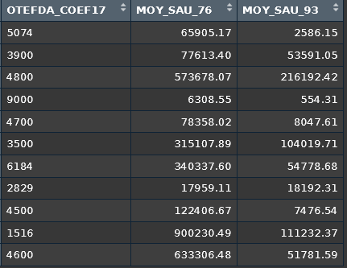

- Re-faites l’exercice avec SQL (ou la syntaxe dplyr)

## 4.28 Pour finir, une comparaison entre {arrow} et {duckdb} (1/2)

Tableau repris de la documentation [utilitr](https://book.utilitr.org/).

| Je souhaite… | arrow | duckdb |
| --- | --- | --- |
| Optimiser mes traitements pour des données volumineuses | ✔️ | ✔️ |
| Travailler sur un fichier .parquet ou .csv sans le charger entièrement en mémoire | ✔️ | ✔️ |
| Utiliser la syntaxe `dplyr` pour traiter mes données | ✔️ | ✔️ |
| Utiliser du langage SQL pour traiter mes données | ❌ | ✔️ |
| Joindre des tables très volumineuses (plus de 4 Go) | ❌ | ✔️ |
| Utiliser des fonctions fenêtres | ❌ | ✔️ |
| Utiliser des fonctions statistiques qui n’existent pas dans arrow | ❌ | ✔️ |
| Écrire un fichier .parquet | ✔️ | ✔️ |

## 4.29 Pour finir, une comparaison entre {arrow} et {duckdb} (2/2)

{arrow} et {duckdb} partagent de nombreux concepts. Voici quelques différences :

- **{duckdb} comprend parfaitement SQL**. Si vous êtes à l’aise avec ce langage, vous ne serez pas dépaysés.
- Le projet duckdb est très récent. Il y a régulièrement des évolutions qui sont souvent des extensions ou des optimisations, et parfois la résolution de bugs. **arrow est un projet plus ancien et plus mature**.
- **La couverture fonctionnelle des fonctions standards de R est meilleure sur {duckdb} que sur {arrow}.**  
  Il est préférable d’utiliser {duckdb} pour les jointures de tables volumineuses.  
  De même, les fonctions `pivot_wider()`, `pivot_longer()` et les `windows_function` existent nativement dans duckdb mais pas dans arrow. Par exemple :

```r
# arrow ne peut pas exécuter ceci
bpe_ens_2022_dataset |>
  group_by(DEP) |>
  mutate(NB_EQUIP_TOTAL_DEP  = sum(NB_EQUIP)) |>
  select(DEP, NB_EQUIP, NB_EQUIP_TOTAL_DEP)
```

```r
# Source:   SQL [?? x 3]
# Database: DuckDB v0.9.2 [unknown@Linux 6.5.0-1024-azure:R 4.3.2/:memory:]
# Groups:   DEP
   DEP   NB_EQUIP NB_EQUIP_TOTAL_DEP
   <chr>    <dbl>              <dbl>
 1 09           2               7316
 2 09           3               7316
# ℹ more rows
```

# 5 Pour en savoir plus

## 5.1 Conseil de lecture

Pour ceux qui veulent aller plus loin :

- Comment bien utiliser le package `arrow` ? C’est par [ici](https://book.utilitr.org/03_Fiches_thematiques/Fiche_arrow.html)
- Comment utiliser DuckDB sur des fichiers au format Parquet ? C’est par [là](https://www.icem7.fr/outils/3-explorations-bluffantes-avec-duckdb-1-interroger-des-fichiers-distants/)
- Comment requêter des fichiers au format Parquet avec Python ? Lien vers la [documentation](https://arrow.apache.org/docs/python/parquet.html).
- Why Parquet Is the Go-To Format for Data Engineer. Article en anglais très pointu sur la constitution et le fonctionnement des fichiers au format Parquet. Un must-read à lire par [ici](https://luminousmen.com/post/why-parquet-is-the-goto-format-for-data-engineers/).

Note interne écrite par le DEMESIS : voir [ici](https://orion.agriculture/confluence/display/BMIS/Passage+au+format+Parquet)

[figure not shown]